# Logit Regression - One-v-All

Steven Loaiza

July 16, 2018

## Introduction

We are going to build on our Logit Model. The essense of the Logistic Model was for a binary choice, either TRUE or FALSE. What if we have multiple class, or choices what can we do then?

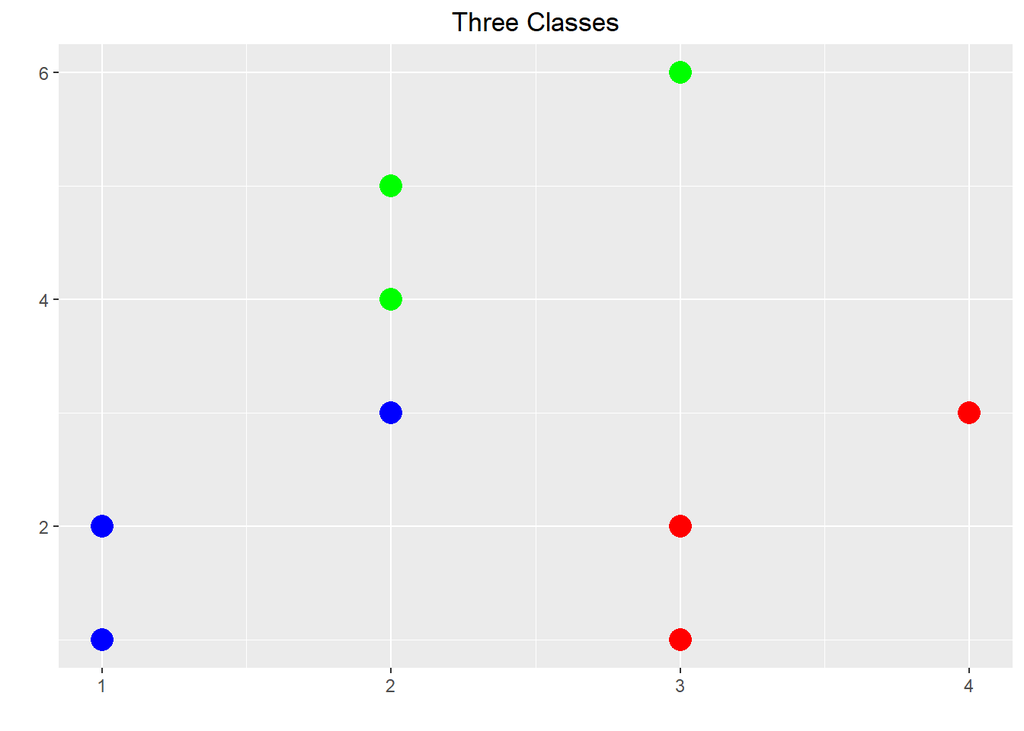

What we will do at this point is to make the data seem like a binary choice and then run the logistic regression minimizing our cost function:
$$J(\beta)=\frac{1}{n}\sum^n_{i=1}(-Y_iln(p(X_i,\beta))-(1-Y_i)ln(1-p(X_i,\beta)))$$
Here we obtain the optimal coefficient, and then we are able to calculate $P(y=1|X,\theta)=h_{\theta}^{i}(x)$ where (i) is the index for the class we concentrated on.

## Visualization

For instance lets make the graph inclusive vs non-inclusive.

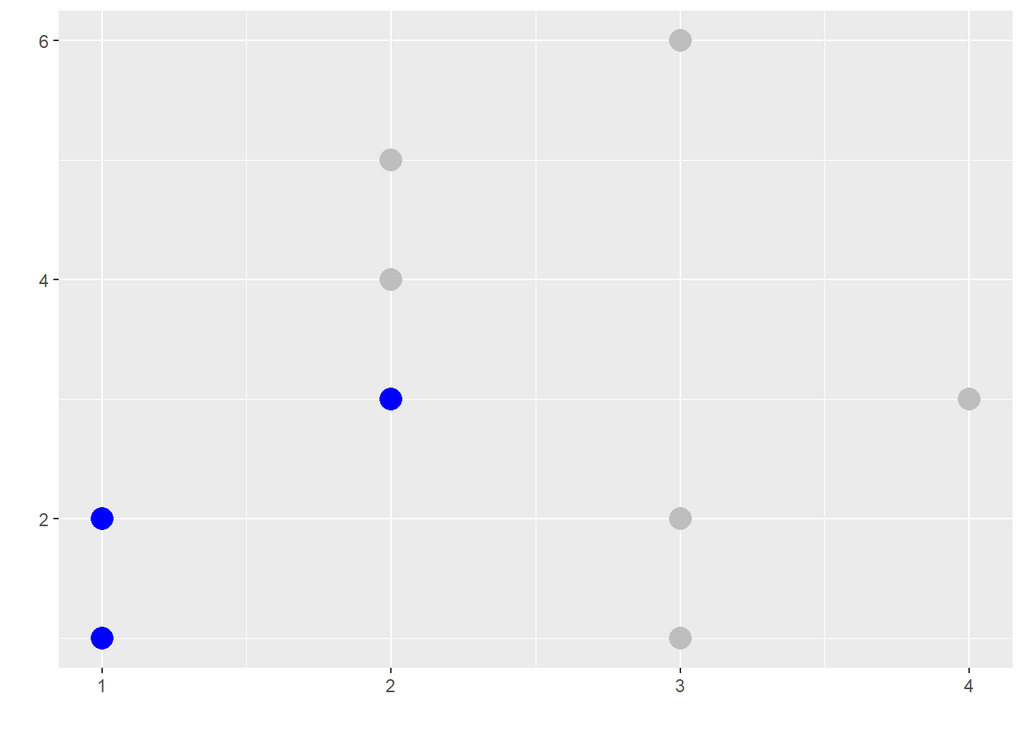

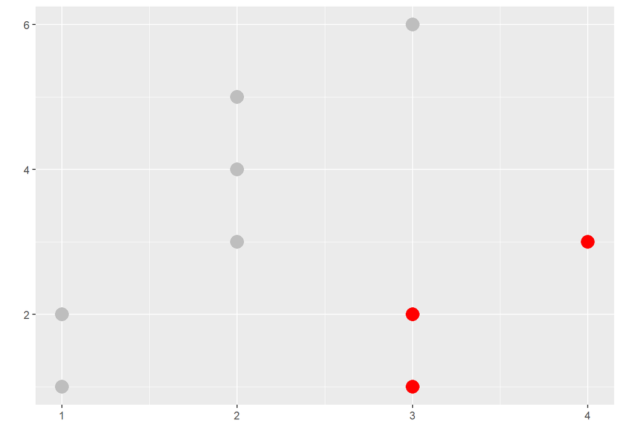

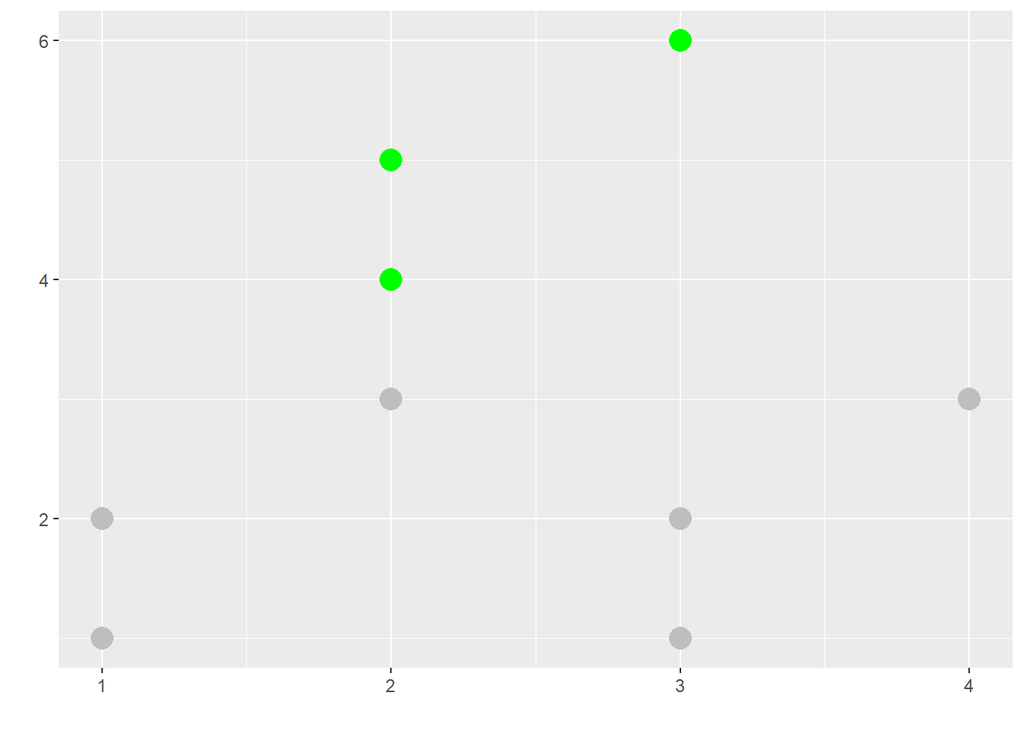

Once we have computed the logit regression for all of the graphs above. We can compute our prediciton using
$$h_{\theta}^{i}(x) \space \forall \space i \epsilon I$$
and then just choose the maximum as the likely prediciton.

# Appendix

Recall from logistic regression that the sigmoid function is what we will use to “predict” our model. $P(y=1|X,\theta)=h_{\theta}^{i}(x)=\frac{1}{1+e^{-X'\theta}}$